# PA1_template.Rmd

Kaitlyn McGrew

1/7/2018

# Reproducable Research Coursera

## week 2 assignment

Load the data from the url in the git repo

```r
data_set <- read.csv("activity.csv")
```

add all the steps take per day and change date to numeric

```r
steps_day <- aggregate(data_set$steps, by=list(data_set$date), FUN=sum)
colnames(steps_day) <- c("Date", "Steps")
steps_day1 <- transform(steps_day, Date = as.numeric(Date))
```

Create a histogram of total steps per day (days with NA values ignored)

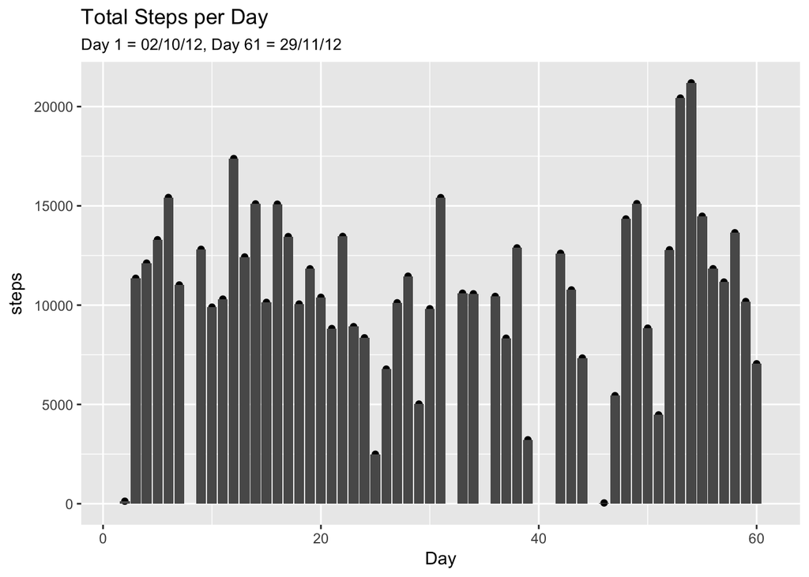

```r
library(ggplot2)
qplot(Date, Steps, data = steps_day1) +
        geom_histogram(stat = "identity") +
        ggtitle("Total Steps per Day",
                subtitle = "Day 1 = 02/10/12, Day 61 = 29/11/12") +
        ylab("steps") + xlab("Day")
```

```r
mean_steps <- mean(steps_day$Steps, na.rm = TRUE)
median_steps <- median(steps_day$Steps, na.rm = TRUE)
```

Arrange the data so its average steps take per time interval

```r
average_date <- aggregate(data_set$steps, by=list(data_set$interval), FUN=mean, na.rm = TRUE)
colnames(average_date) <- c("Time_Interval", "Average_steps")
```

Create a time series plot showing average steps taken by time interval

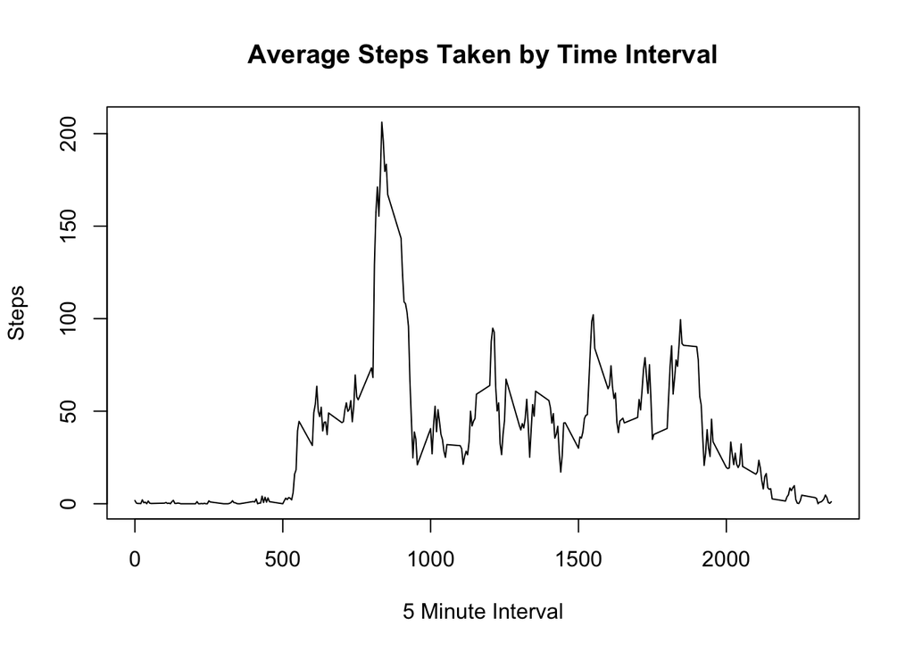

```r
plot(average_date$Time_Interval, average_date$Average_steps, type = "l",
     main = "Average Steps Taken by Time Interval",
     ylab = "Steps",
     xlab = "5 Minute Interval")
```

Determine which interval on average has the max number of steps

```r
max_steps <- average_date[which.max(average_date$Average_steps), ]
```

Find the total number of missing values in the report

```r
number_na <- sum(is.na(data_set))
```

I plan to replace the NA values with the mean number of steps for that interval.

```r
corrected_data <- data_set
corrected_data$steps[which(is.na(corrected_data$steps))] <- average_date$Average_steps
```

create a new histogram like the first of the corrected data set

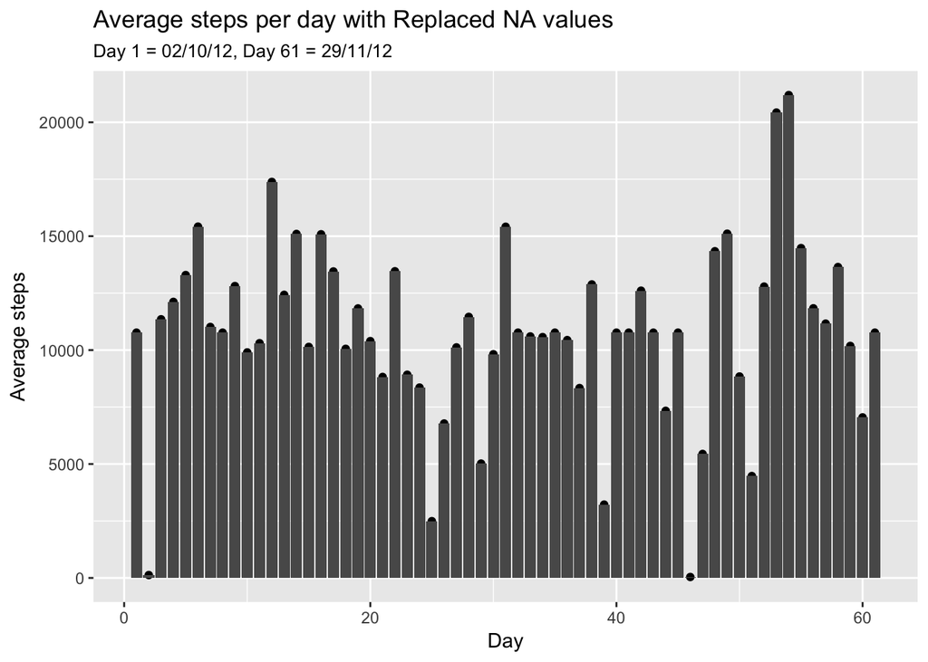

```r
library(ggplot2)
corrected_data1 <- transform(corrected_data, date = as.numeric(date))
corrected_average_steps <- aggregate(corrected_data1$steps, by=list(corrected_data1$date), FUN=sum)
colnames(corrected_average_steps) <- c("date", "steps")
qplot(date, steps, data = corrected_average_steps) +
        geom_histogram(stat = "identity") +
        ggtitle("Average steps per day with Replaced NA values",
                subtitle = "Day 1 = 02/10/12, Day 61 = 29/11/12") +
        ylab("Average steps") +
        xlab("Day")
```

calculate the mean and median of the new data set

```r
corrected_mean <- mean(corrected_data$steps, na.rm = TRUE)
corrected_median <- median(corrected_average_steps$steps, na.rm = TRUE)
```

create a new variable that shows if the date was on a weekend or weekday

```r
library(dplyr)
new_data_set <- data_set
new_data_set <- transform(new_data_set, date = as.Date(date))
new_data_variable <- mutate(new_data_set, day_of_week = weekdays(new_data_set$date))
week_day_data <- new_data_variable[new_data_variable$day_of_week %in% c("Monday", "Tuesday", "Wednesday", "Thursday", "Friday"), ]
week_end_data <- new_data_variable[new_data_variable$day_of_week %in% c("Saturday", "Sunday"), ]
```

Now create a 2 panel time series plot of weekend and weekday average steps by time interval

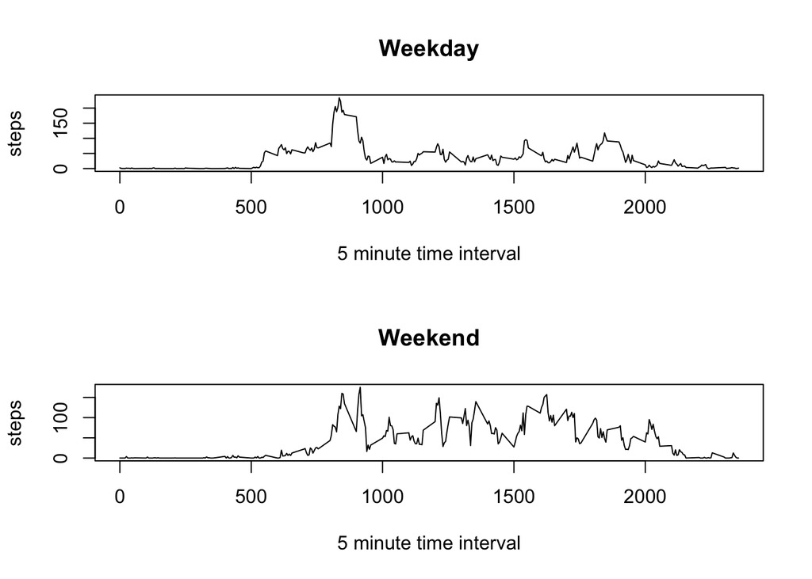

```r
week_day_average <- aggregate(week_day_data$steps, by=list(week_day_data$interval), FUN=mean, na.rm = TRUE)
colnames(week_day_average) <- c("Interval", "steps")
week_end_average <- aggregate(week_end_data$steps, by=list(week_end_data$interval), FUN=mean, na.rm = TRUE)
colnames(week_end_average) <- c("Interval", "steps")
par(mfcol= c(2,1))
 plot(week_day_average$Interval, week_day_average$steps, type = "l",
      xlab = "5 minute time interval",
      ylab = "steps",
      main = "Weekday")
 plot(week_end_average$Interval, week_end_average$steps, type = "l",
      xlab = "5 minute time interval",
      ylab = "steps",
      main = "Weekend")
```